# Survival Analysis

Kamil Seghrouchni

5/11/2020

## Introduction

The *Primary biliary cholangitis* (PBC) or *primary biliary cirrhosis* is a autoimmune disease leading to bile release in the liver[1]. One of the major role of the liver is bile production, a secretion involved in cholesterol and other cell wastes processing. For that matter, bile is being further transported to the digestive apparatus parlty through bile ducts. PBC is being experienced as bile conduct damages causing liver tissue scarring upon bile release leading to liver malfunction or failure of such organ[2]. As liver is one of the body vital organs, PBC in its latest stages unfortunalty leads to patient death if he is not subject to liver transplant.

In order to better diagnose and cure PBC, it is of the outmost importance to understand the risk factors and metrics indicators of such disease as well as the potential effect of given drug therapies. Mayo clinic trial have been aiming at performing a randomized placebo clinic test for D-penicillamine[3], a drug meant for PBC treatment. They have gathered a data set of 424 PBC patients in a ten year interval. Although most interests have been around drug therapy investigation, this trial also assesses other auxilary variables such as clinical and biological metrics.

This study consists of a Survival Analysis based on Mayo Clinic trial data set. In fact, it aims at investigating the outcome of D-pencilamine as well as other clinical and bilogical metrics on the survival probability of patients with PBC. Such investigation has been conducted through Keplen-Meyer estimates of the survival function. Further analysis of the data also lead to Cox regression to fit the hazard function of the resulting model. Explory data anlysis was also performed in this study to get a better grasp of the data set other characteristics.

## Exploratory Data analysis

- DRUG : Tratment groups : 1 for D-penicilamine, 2 for placebo, “.” for extra trial patients
- AGE : Patients age
- ASCITES : Abnormal buildup of abdomen fluid (wiki) : 0 = absent, 1=present
- HEPATOMES : Enlarged liver (wiki) : 0=absent 1=present
- SPIDERS : Spider angiomas : 0=absent 1=present
- EDEMA : Edema presence: 0=absent without diuretic therapy for edema; .5 = present without or resolved by diuretics, 1 = present despite diuretic therapy
- BILI : serum bilirubin concentration in mg/dl
- CHOL : serum cholesterol concentration in mg/dl
- ALBUMIN : albumin concentration in gm/dl
- COOPER :urine copper concentration in ug/day
- ALKPHOS : alkaline phosphatase concentration in U/liter
- SGOT: Aspartate transaminase concentration in U/ml
- TRIG : triglicerides concentration in mg/dl
- PLATELETS : platelets concentration per cubic ml / 1000
- PROTIME : prothrombin time in seconds
- STAGE : histologic stage of disease going from 1 to 4,4 being the terminal one.

First data analysis showed a certain amount of missing data. In fact, the extra trail patients were not followed up for ascites, hepatomes, alkaline phosphatase, cholesterol, aspartate transaminsase and urine cooper. As our data is both composed of continuous and categorical variables, data exploration had to be perfomed accordingly and as such, histograms were used to display the categorical variables distributions where as boxplots of were realized for the continuous ones.

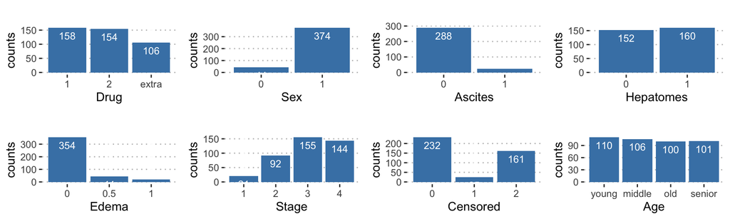

Barplot of selected variables: Drug treamtment,Sex of patients, presence of Ascites, presence of Hepatomes, presence of Edma, Stage of the disease, Status of disease, Age of patients

Data distribution across categories allows to apprehend how balanced the various fatures are. As depicted in figure , the trial comprised less male patients, less patients having ascites and no edema. The majority of patients enrolled in the trial are in late stages of the desease (3 or 4). On the other hand, it is seen that the number of patients in both the control and treamtent group is more less the same as well as for the prensence and absence of hepatomes and patient distribution across age groups. It is also observed that transplanted patients only account for 25 of the cases. Finally as pbc is responsible for liver failure and induced death, it is important to investigate such event of interest related to disease stage.

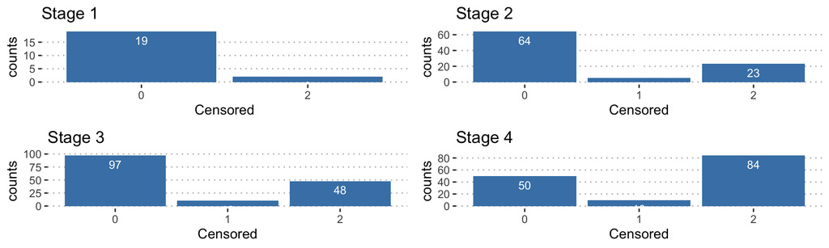

Barplot of censored data repartition across disease stages

Getting insights on data distribution is also a key aspect of exploratory analysis on bivariate data. As such, boxploting the different variables in Figure provides a five number visual summary on each distribution. Length of the boxplot is defined as the interquartile range which is the difference between first and third quartile. The larger it is, the sparser the data is. Hence, one can mention the high diversity in trial days as it encompass a sparse time frame periode with a median of 1730 as well as for the age of the enrolled patients (median : approximatly 51 years old). As for the other variables boxplots appear to be quite narrow, they seem to display many outliers. However, such outlier are much more numerous for bilirubin, cholesterol, urine cooper and alkaline phosphatase concentrations. Those outliers might come from higher concentrations or higher metric values experienced for uncesored data. Indentifying explanatory variables will help us understand the underlying reason for such observations.

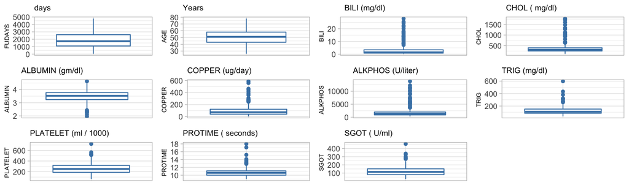

Boxplots of continuous variables